# How to Ace STAT5

Probability Statistics Correlation

# Statistics

In statistics, we believe that everything we observe is a random process, and we want to model those processes.

## Sampling

To learn anything about the world we need data, and we get our data by sampling. A sampling process looks like this:

1. Identify population of interest
2. Pick an appropriate sampling method
3. Generate sample

### Simple Random Sampling

With Simple Random Sampling, we choose some $n$ members of the population at random as our sample. This is usually considered the ideal sampling method.  
Example:  
We want to know about midterm grades in STAT 5. We can randomly select 20 students from the class and check their midterm scores.  
**Population:** All STAT5 midterm scores  
**Sample:** The 20 selected student’s midterm scores.

### Stratified Random Sampling

We group the population, then sample from each group. This is often used in medical studies where it is important to have a diverse set of test subjects.  
Example:  
We want to know about midterm grades in STAT 5. We can randomly select 5 students from each discussion section and check their midterm scores.  
**Population:** All STAT5 midterm scores  
**Sample:** The 5 students from each discussion section’s midterm scores

### Cluster Sampling

We group the population, then randomly select some groups This can be used when physically collecting the data is costly, so it is more efficient to sample groups of people at multiple locations.  
Example:  
We want to know about midterm grades in STAT 5. We can randomly select 2 discussion sections and check all of those student’s midterm scores.  
**Population:** All STAT5 midterm scores  
**Sample:** The students from both selected discussion section’s midterm scores

### Systematic Sampling

This is not random. Instead, we systematically select individuals to form a sample.  
Example:  
We want to know about midterm grades in STAT 5. We select every 3rd student by last name  
**Population:** All STAT5 midterm scores  
**Sample:** Every 3rd student by last name’s midterm scores.

## Statistics

A **Statistic** is any function of the sample. We usually only think about useful statistics, like the mean, median, or standard deviation.

These are the most common statistics you will see

```r
sample = c(11, 12, 22, 1, 34, 77, 91, 9, 50)
```

### Order Statistics

We calculate these based off ordering the sample

```r
sort(sample)
```

```
## [1]  1  9 11 12 22 34 50 77 91
```

| Statistic | Value | Formula |
| --- | --- | --- |
| min | 1 | the smallest value in the sample |
| Q1 | 11 | the sample, in order, halfway between the min and median |
| median | 22 | the sample, in order, halfway between the max and min |
| Q3 | 50 | the sample, in order, halfway between the median and max |
| max | 91 | the largest value in the sample |
| IQR | 39 | Q3-Q1 |

These are somewhat hard to deal with probabilistically, but when dealing with data with outliers or high skew, these are better than the direct statistics

### Direct Statistics

These statistics come directly from the sample, and have nicer probabilities to calculate.

[output not shown]

These are much nicer to work with in general, so when we can use them, we do.

When we have data with two variables, we might want to see the relationship between them. For this, we use **Correlation**.
$$Cor(X,Y) =
\frac{1}{sqrt{Var(X)Var(Y)}}\sum_{i=1}^n(x_i-\bar{x})\sum_{j=1}^m(y_i-\bar{y})\$$
This takes values between -1 and 1, where 1 means a strong positive correlation, i.e. an increase in $X$ leads to an increase in $Y$, and -1 means a strong negative correlation, i.e. an increase in $X$ leads to a decrease in $Y$ and vice versa. Values near 0 mean no correlation either way.

### Why choose Direct or Order statistics?

The easiest way to see the difference between the two is comparing the mean and median. Think about a sample where every value is 0.

```r
sample <- c(0, 0, 0, 0, 0)
```

Then the mean and median are both 0.  
Now, imagine we add one sample with a value of 10.

```r
sample <- c(0, 0, 0, 0, 0, 10)
# Calculate the mean
mean(sample)
```

```
## [1] 1.666667
```

```r
# Calculate the median
quantile(sample, probs=.5)
```

```
## 50%
##   0
```

The median is not affected by outliers, while the mean is.

## Visualizations

We usually start any data analysis with some visualizations of our data, to understand what models to use. For this section, I’ll use the `mtcars` dataset built in to `R`. This dataset contains mpg information about a bunch of cars.

### Histogram

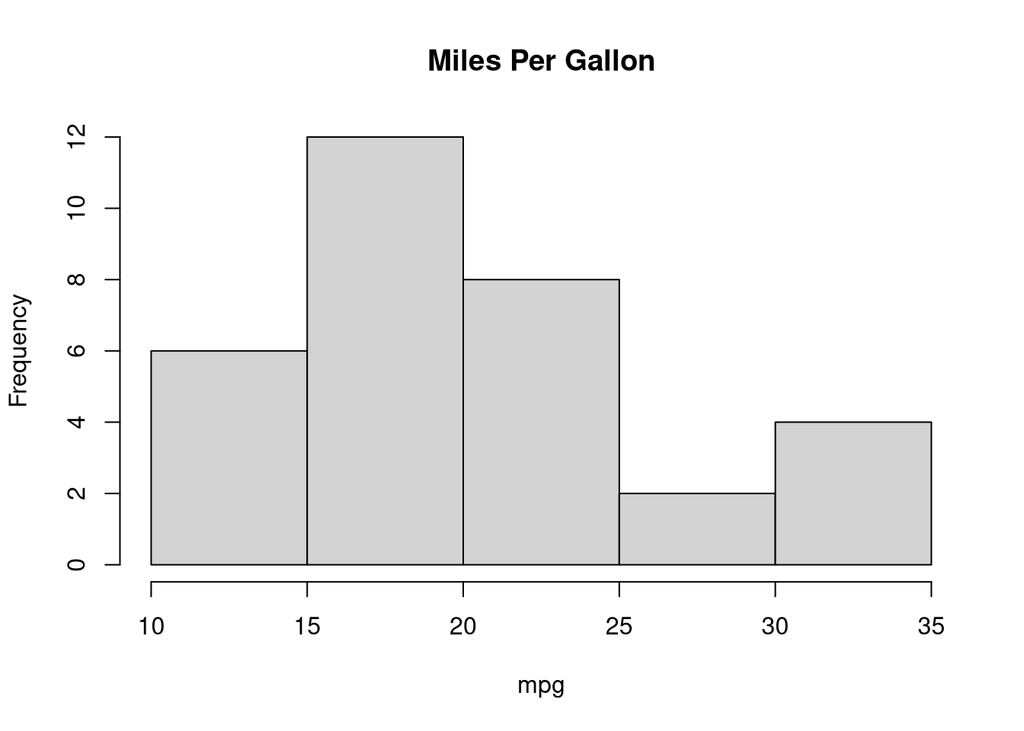

```r
attach(mtcars)
hist(mpg, main="Miles Per Gallon")
```

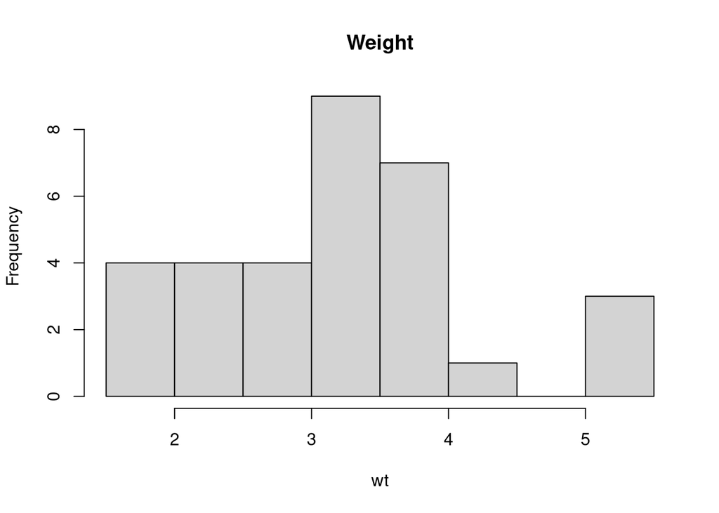

```r
hist(wt, main="Weight")
```

A histogram is a plot of the frequency of each value in a sample. This is a one dimensional plot tracking one variable.

Histograms are also a very easy way to see skew and outliers. If there are more data points to the left of the peak than to the right of the peak, the data is left skewed. If there are more data points to the right of the peak than to the left of the peak, the data is right skewed.

### Bar Graph

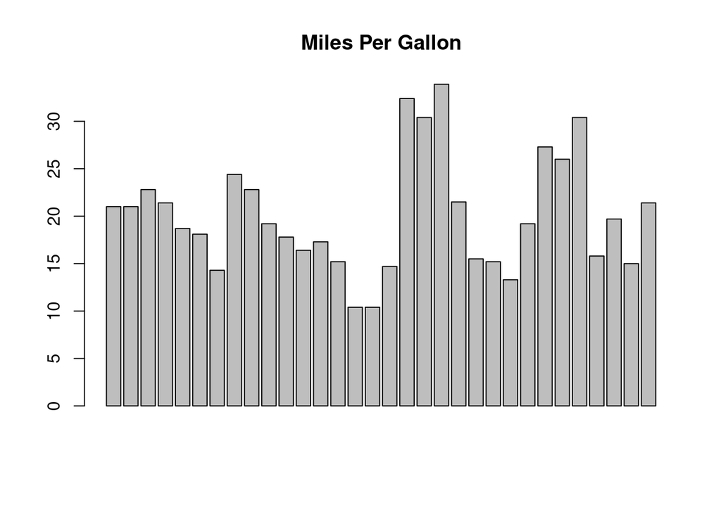

```r
barplot(mpg, main="Miles Per Gallon")
```

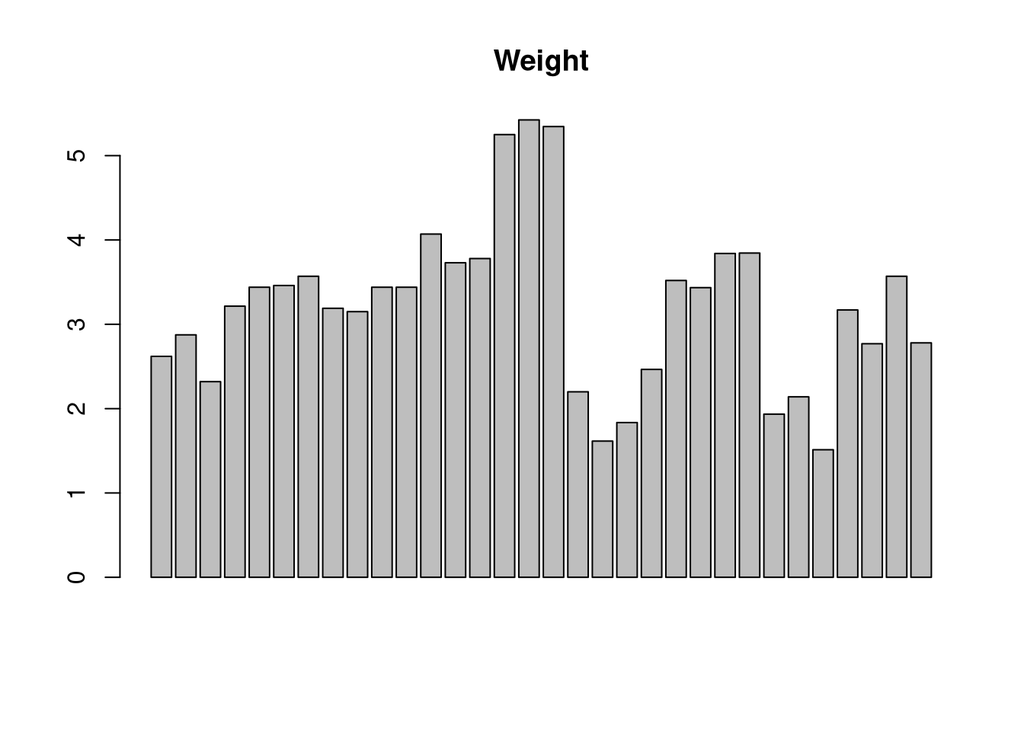

```r
barplot(wt, main="Weight")
```

Bar graphs show the value at each sample. While visually similar to the histogram, we can see that these contain very different information.

### Stem and Leaf plot

```r
stem(mpg)
```

```
##
##   The decimal point is at the |
##
##   10 | 44
##   12 | 3
##   14 | 3702258
##   16 | 438
##   18 | 17227
##   20 | 00445
##   22 | 88
##   24 | 4
##   26 | 03
##   28 |
##   30 | 44
##   32 | 49
```

This is essentially equivalent to the histogram, but shows the precise values rather than any ‘binning’, or considering two very similar values to be the same for plotting.

### Scatterplot

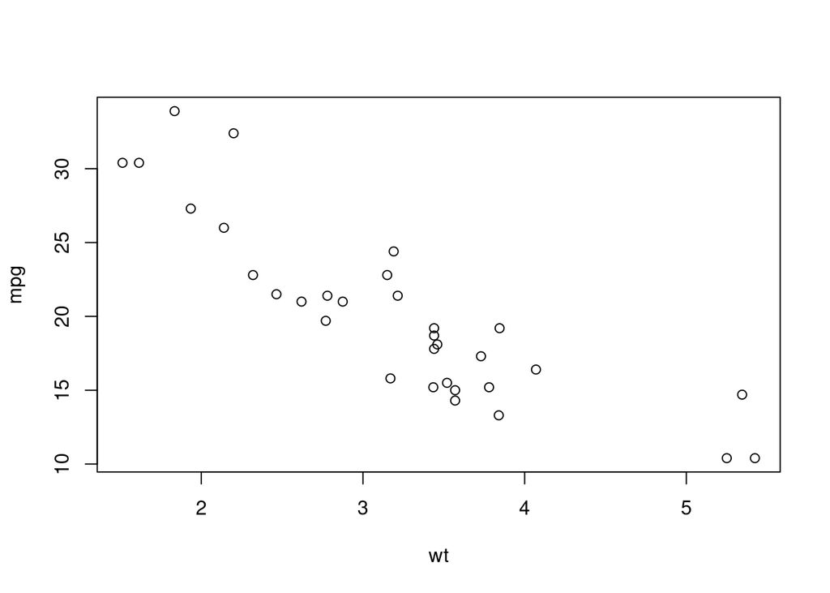

```r
plot(mpg ~ wt)
```

The scatterplot is a multidimensional plot showing each sample as a point, with each axis representing one random variable tracked. These are often used for linear regression.

## Estimators

Because we believe that everything we observe comes from some probability distribution, we want to estimate the parameters that control the probability distribution.

Often times, we model using Normal or Binomial distributions, which are parameterized by their mean.

### Normal Model (unknown mean)

Let (all independent)
$$X_1,...,X_n \sim N(\mu, \sigma)$$
where $\sigma$ is the known standard deviation and $\mu$ is the unknown true mean. We can *estimate* $\mu$ by $\hat\mu = \bar{x} = \frac{1}{n}\sum_{i=1}^nX_i$ the sample mean.

### Binomial Model

Let (all independent)
$$Y_1, ..., Y_n \sim Bin(n, p)$$
where $p$ is the unknown true population proportion. We can *estimate* $p$ by $\hat p = \frac{1}{n}\sum_{i=1}^nY_i$.

### Linear Regression

Let
$$Y_i = \beta_0 + \beta_1 X_i + \epsilon_i, \quad \epsilon_i \sim
N(0,\sigma^2) independent$$
Where $Y_i, X_i$ are known, and we want to find $\beta_0, \beta_1$ such that $\sigma^2$ is minimized. This models a linear relationship between the random variables $Y,X$.

The **Intercept** term has estimator $\hat\beta_0 = \bar{Y}$.  
The **Slope** term has estimator $\hat \beta_1 = (X^TX)^{-1}X^T(Y-\hat\beta_0)$.  
These estimators will not be tested, however interpretation of a linear regression model will.

**Interpretations:**  
The **Slope** $\beta_1$ is always interpretable, it represents the change in $Y$ corresponding to a 1 unit change in $X$.  
The **Intercept** $\beta_0$ is the estimated value of $Y$ when $X=0$. This is interpretable when 0 is in the range of $X$.  
For example, in our `mtcars` dataset,

```r
summary(lm(mpg ~ wt))
```

```
##
## Call:
## lm(formula = mpg ~ wt)
##
## Residuals:
##     Min      1Q  Median      3Q     Max
## -4.5432 -2.3647 -0.1252  1.4096  6.8727
##
## Coefficients:
##             Estimate Std. Error t value Pr(>|t|)
## (Intercept)  37.2851     1.8776  19.858  < 2e-16 ***
## wt           -5.3445     0.5591  -9.559 1.29e-10 ***
## ---
## Signif. codes:  0 '***' 0.001 '**' 0.01 '*' 0.05 '.' 0.1 ' ' 1
##
## Residual standard error: 3.046 on 30 degrees of freedom
## Multiple R-squared:  0.7528, Adjusted R-squared:  0.7446
## F-statistic: 91.38 on 1 and 30 DF,  p-value: 1.294e-10
```

We get an estimated intercept of 37.2851 and estimated slope of -5.3445. The slope is interpreted as “for every 1 unit increase in weight, we expect the miles per gallon to *decrease* by 5.3445”.  
The intercept is interpreted as “a vehicle that weighs 0 units is expected to get 37.2851 miles per gallon, this is not interpretable because there are no cars with weight near or equal to 0”.

## Hypothesis Testing

Everything above is great for fitting statistical models to data, but that only gives us estimates of where the data implies parameters are. People are generally not satisfied by these fuzzy results, and want to use statistics to make decisions.

In general, we like to use Hypotheses as below
$$H_0 : \theta = \theta_0 \quad \text{ versus }\quad H_1: \theta
\neq \theta_0$$
Where $X_1,...,X_n \sim f(X|\theta)$ are parameterized by $\theta$.

We call $H_0$ the **Null Hypothesis** and $H_1$ as the **Alternative Hypothesis**.

We evaluate using the *Likelihood* of $H_0$, that is,
$$P(|\hat\theta| \geq k|\theta=\theta_0)$$
Where $\hat\theta$ is the estimator of $\theta$ generated by the data. We set the value of $k$ such that under the null hypothesis,
$$P(|\hat\theta| \geq k|\theta=\theta_0) = \alpha$$
This is called the $\alpha$ level test.

### Normal Data Example

Let
$$X_1,...,X_n \sim N(\mu,\sigma^2)$$
Where the mean $\mu$ is unknown, and the variance $\sigma^2$ is known. We can use the Central Limit Theorem, which says our test statistic is
$$\frac{\bar{X}-\mu}{\sqrt{\sigma^2/n}} \to N(0,1)$$
Notice that this term is the formula for a **Z-Score**

Lets generate some data and try it out.

```r
(X <- rnorm(10, mean=5, sd=2))
```

```
##  [1] 3.466408 3.367083 4.716930 4.444790 5.872614 2.626255 7.383974 4.963619
##  [9] 4.503831 4.274126
```

We want to test
$$H_0 : \mu = 0 \text{ versus } H_1: \mu \neq 0$$
at $\alpha=0.05$ Then, under the null hypothesis and the central limit theorem,
$$\frac{\bar{X}}{2/\sqrt{n}} \sim N(0,1)$$
So in our generated data, we have

```r
xbar <- mean(X)
n <- 10
(z.score <- xbar/(2/sqrt(n)))
```

```
## [1] 7.213097
```

Because we are testing against $\mu \neq \mu_0$, there are two extremes to consider, so we need to see a value more extreme than $Z_{\alpha/2} = -1.959964$.  
Our z-score is much larger in absolute value than the cutoff, so we say we *reject the null hypothesis*. Because we assumed that the null hypothesis was true to generate this likelihood, this tells us only that the null is highly unlikely.

Let’s try another test,
$$H_0: \mu = 2 \text{ versus } H_1: \mu < 2$$
at $\alpha=0.05$. Then, under the null hypothesis and the central limit theorem,
$$\frac{\bar{X}-2}{2\sqrt{n}} \sim N(0,1)$$
So in our generated data, we have

```r
xbar <- mean(X)
n <- 10
(z.score <- (xbar-2)/(2/sqrt(n)))
```

```
## [1] 4.050819
```

Now there is only one extreme to consider, we reject the null if we see a value smaller than $Z_\alpha = -1.6448536$.  
Our Z-score is too high, so we *fail to reject the null hypothesis*.

### Binomial/Bernoulli Example

Let
$$X_1,...,X_n \sim Ber(p)$$
with unknown $p$. Using the central limit theorem, our test statistic is
$$\frac{\hat p - p}{\sqrt{(p(1-p)/n}} \to N(0,1)$$
This gives us a Z-score for the sample proportion $\hat p$.

Lets try an example.
Suppose we want to check if a coin is fair. Let heads be “successes” and tails be “failures”. We want to test
$$H_0 : p = 0.5 \text{ versus } H_1: p \neq 0.5$$
at $\alpha = 0.1$.
We flip the coin a 20 times and get the following results

```r
X <- c(1, 1, 0, 1, 0, 0, 1, 0, 1, 1, 1, 0, 1, 0, 1, 1, 0, 0, 1, 1)
(n <- length(X))
```

```
## [1] 20
```

```r
(phat <- sum(X)/n)
```

```
## [1] 0.6
```

Now we can calculate the z-score of our estimator under the null hypothesis.

```r
(z.score <- (phat - 0.5)/sqrt(0.5*(1-0.5)/n))
```

```
## [1] 0.8944272
```

This Z-score is less extreme than the cutoff $Z_{\alpha/2} = -1.6448536$, so we *fail to reject* the null hypothesis that the coin is fair.

## Confidence and p-values

These are both related heavily to hypothesis testing. A **p-value** is the likelihood of getting a value as extreme or more extreme than the test statistics from the previous section. If they are smaller than the set $\alpha$ level, we reject the null hypothesis.

Confidence intervals are a little more interesting.

### Normal Data

The $1-\alpha$ confidence interval for $\mu$ can be found via the test statistic. With probability $1-\alpha$,
$$\begin{aligned}
\left|\frac{\bar{X}-\mu}{\sqrt{\sigma^2/n}}\right| &\leq
Z_{\alpha/2} \\
\implies -Z_{\alpha/2} \leq
\frac{\mu-\bar{X}}{\sqrt{\sigma^2/n}} &\leq Z_{\alpha/2} \\
\implies -Z_{\alpha/2}\sqrt{\frac{\sigma^2}{n}} \leq \mu-\bar{X}
&\leq Z_{\alpha/2}\sqrt{\frac{\sigma^2}{n}} \\
\implies \bar{X} - Z_{\alpha/2}\sqrt{\frac{\sigma^2}{n}} \leq
\mu &\leq \bar{X} + Z_{\alpha/2}\sqrt{\frac{\sigma^2}{n}} \\
\end{aligned}$$
We can see that the limits of the interval are random, so we are estimating a *region* where the parameter may be. Under the null hypothesis, $(1-\alpha)100\%$ of these intervals will contain the true parameter $\mu$.

### Binomial/Bernoulli Data

The $1-\alpha$ confidence interval for $p$ can be calculated similarly, the result is
$$\hat p - Z_{\alpha/2}\sqrt{\frac{\hat p(1-\hat p)}{n}} \leq p
\leq \hat p + Z_{\alpha/2}\sqrt{\frac{\hat p(1-\hat p)}{n}}$$

### General considerations

We can see a few properties from both of these. Firstly, increasing confidence increases the value of $Z_{\alpha/2}$, so the interval becomes larger with increased confidence.  
Think about this as “adding more guesses” so that the interval is right more often.